# Title : Google Playstore App Rating prediction using best Model

### Introduction

In predicting the rating of Apps in playstore there are many criterias which we have go through inorder to predict the best model for this data. Our dataset consists of some of the main criterias that are valid for the prediction of rating. Our dataset includes following variables that are taken in to consideration, Apps, Category, Reviws, Size, Installs, Type, Price, Content Rating , LastUpdated ,Genres, Current version, Android version.

```python
#Importing the necessary libraries
import pandas as pd
import numpy as np
import matplotlib.pyplot as plt
import seaborn as sns
import warnings
warnings.filterwarnings('ignore')
```

```python
#Loading the dataset
data =pd.read_csv('C:/Users/ASUS/Downloads/googleplaystore.csv')
data.head()
```

|  | App | Category | Rating | Reviews | Size | Installs | Type | Price | Content Rating | Genres | Last Updated | Current Ver | Android Ver |
| --- | --- | --- | --- | --- | --- | --- | --- | --- | --- | --- | --- | --- | --- |
| 0 | Photo Editor & Candy Camera & Grid & ScrapBook | ART_AND_DESIGN | 4.1 | 159 | 19M | 10,000+ | Free | 0 | Everyone | Art & Design | January 7, 2018 | 1.0.0 | 4.0.3 and up |
| 1 | Coloring book moana | ART_AND_DESIGN | 3.9 | 967 | 14M | 500,000+ | Free | 0 | Everyone | Art & Design;Pretend Play | January 15, 2018 | 2.0.0 | 4.0.3 and up |
| 2 | U Launcher Lite – FREE Live Cool Themes, Hide ... | ART_AND_DESIGN | 4.7 | 87510 | 8.7M | 5,000,000+ | Free | 0 | Everyone | Art & Design | August 1, 2018 | 1.2.4 | 4.0.3 and up |
| 3 | Sketch - Draw & Paint | ART_AND_DESIGN | 4.5 | 215644 | 25M | 50,000,000+ | Free | 0 | Teen | Art & Design | June 8, 2018 | Varies with device | 4.2 and up |
| 4 | Pixel Draw - Number Art Coloring Book | ART_AND_DESIGN | 4.3 | 967 | 2.8M | 100,000+ | Free | 0 | Everyone | Art & Design;Creativity | June 20, 2018 | 1.1 | 4.4 and up |

```python
## Renaming the columns to make it easier for python to understand
data = data.rename(columns = {'Content Rating':'Content_Rating','Current Ver':'Current_Ver','Android Ver':'Android_Ver'})
```

```python
data.shape
```

```
(10841, 13)
```

```python
data.info()
```

```
<class 'pandas.core.frame.DataFrame'>
RangeIndex: 10841 entries, 0 to 10840
Data columns (total 13 columns):
 #   Column          Non-Null Count  Dtype
---  ------          --------------  -----
 0   App             10841 non-null  object
 1   Category        10841 non-null  object
 2   Rating          9367 non-null   float64
 3   Reviews         10841 non-null  object
 4   Size            10841 non-null  object
 5   Installs        10841 non-null  object
 6   Type            10840 non-null  object
 7   Price           10841 non-null  object
 8   Content_Rating  10840 non-null  object
 9   Genres          10841 non-null  object
 10  Last Updated    10841 non-null  object
 11  Current_Ver     10833 non-null  object
 12  Android_Ver     10838 non-null  object
dtypes: float64(1), object(12)
memory usage: 1.1+ MB
```

## Data cleaning

```python
data[data['Rating'] > 5] # checking for our target column to find wheather a value greater than 5
```

|  | App | Category | Rating | Reviews | Size | Installs | Type | Price | Content_Rating | Genres | Last Updated | Current_Ver | Android_Ver |
| --- | --- | --- | --- | --- | --- | --- | --- | --- | --- | --- | --- | --- | --- |
| 10472 | Life Made WI-Fi Touchscreen Photo Frame | 1.9 | 19.0 | 3.0M | 1,000+ | Free | 0 | Everyone | NaN | February 11, 2018 | 1.0.19 | 4.0 and up | NaN |

```python
rec = data[data['Category'] == '1.9'].index
data = data.drop(rec)
```

```python
# Drop the columns which have no impact
data = data.drop(columns=['App', 'Last Updated', 'Current_Ver', 'Android_Ver'])
```

```python
#splitting the dataset into train and test
data_test=data[data['Rating'].isnull()]
data_test
```

|  | Category | Rating | Reviews | Size | Installs | Type | Price | Content_Rating | Genres |
| --- | --- | --- | --- | --- | --- | --- | --- | --- | --- |
| 23 | ART_AND_DESIGN | NaN | 61 | 7.0M | 100,000+ | Free | 0 | Everyone | Art & Design;Action & Adventure |
| 113 | BEAUTY | NaN | 182 | 5.7M | 100,000+ | Free | 0 | Everyone 10+ | Beauty |
| 123 | BEAUTY | NaN | 119 | 3.7M | 50,000+ | Free | 0 | Everyone | Beauty |
| 126 | BEAUTY | NaN | 654 | 7.4M | 100,000+ | Free | 0 | Teen | Beauty |
| 129 | BEAUTY | NaN | 77 | 2.9M | 10,000+ | Free | 0 | Mature 17+ | Beauty |
| ... | ... | ... | ... | ... | ... | ... | ... | ... | ... |
| 10824 | MEDICAL | NaN | 67 | 82M | 10,000+ | Free | 0 | Everyone | Medical |
| 10825 | SOCIAL | NaN | 7 | 7.7M | 100+ | Free | 0 | Teen | Social |
| 10831 | MAPS_AND_NAVIGATION | NaN | 38 | 9.8M | 5,000+ | Free | 0 | Everyone | Maps & Navigation |
| 10835 | BUSINESS | NaN | 0 | 9.6M | 10+ | Free | 0 | Everyone | Business |
| 10838 | MEDICAL | NaN | 3 | 9.5M | 1,000+ | Free | 0 | Everyone | Medical |

1474 rows × 9 columns

```python
data_train =data.copy()
data_train.dropna(subset=['Rating'],inplace =True)
data_train
```

|  | Category | Rating | Reviews | Size | Installs | Type | Price | Content_Rating | Genres |
| --- | --- | --- | --- | --- | --- | --- | --- | --- | --- |
| 0 | ART_AND_DESIGN | 4.1 | 159 | 19M | 10,000+ | Free | 0 | Everyone | Art & Design |
| 1 | ART_AND_DESIGN | 3.9 | 967 | 14M | 500,000+ | Free | 0 | Everyone | Art & Design;Pretend Play |
| 2 | ART_AND_DESIGN | 4.7 | 87510 | 8.7M | 5,000,000+ | Free | 0 | Everyone | Art & Design |
| 3 | ART_AND_DESIGN | 4.5 | 215644 | 25M | 50,000,000+ | Free | 0 | Teen | Art & Design |
| 4 | ART_AND_DESIGN | 4.3 | 967 | 2.8M | 100,000+ | Free | 0 | Everyone | Art & Design;Creativity |
| ... | ... | ... | ... | ... | ... | ... | ... | ... | ... |
| 10834 | FAMILY | 4.0 | 7 | 2.6M | 500+ | Free | 0 | Everyone | Education |
| 10836 | FAMILY | 4.5 | 38 | 53M | 5,000+ | Free | 0 | Everyone | Education |
| 10837 | FAMILY | 5.0 | 4 | 3.6M | 100+ | Free | 0 | Everyone | Education |
| 10839 | BOOKS_AND_REFERENCE | 4.5 | 114 | Varies with device | 1,000+ | Free | 0 | Mature 17+ | Books & Reference |
| 10840 | LIFESTYLE | 4.5 | 398307 | 19M | 10,000,000+ | Free | 0 | Everyone | Lifestyle |

9366 rows × 9 columns

```python
data_train.info()
```

```
<class 'pandas.core.frame.DataFrame'>
Int64Index: 9366 entries, 0 to 10840
Data columns (total 9 columns):
 #   Column          Non-Null Count  Dtype
---  ------          --------------  -----
 0   Category        9366 non-null   object
 1   Rating          9366 non-null   float64
 2   Reviews         9366 non-null   object
 3   Size            9366 non-null   object
 4   Installs        9366 non-null   object
 5   Type            9366 non-null   object
 6   Price           9366 non-null   object
 7   Content_Rating  9366 non-null   object
 8   Genres          9366 non-null   object
dtypes: float64(1), object(8)
memory usage: 731.7+ KB
```

```python
data_train['Size'].unique()
```

[output not shown]

```python
data_train['Size'] = data_train['Size'].apply(lambda x : str(x).replace('M',''))
data_train['Size'] = data_train['Size'].apply(lambda x : str(x).replace('+',''))
data_train['Size'] = data_train['Size'].apply(lambda x : str(x).replace(',',''))
data_train['Size'] = data_train['Size'].apply(lambda x : str(x).replace('Varies with device','nan'))
data_train['Size'] = data_train['Size'].apply(lambda x :float(str(x).replace('k',''))/1000 if 'k' in str(x) else x)
data_train['Size']= data_train['Size'].astype(float)
data_train.dropna(subset=['Size'],inplace =True)
```

```python
data_train['Reviews'].unique()
```

```
array(['159', '967', '87510', ..., '603', '1195', '398307'], dtype=object)
```

```python
data_train['Reviews'] = data_train['Reviews'].apply(lambda x : str(x).replace('M',''))
data_train['Reviews']= data_train['Reviews'].astype(float)
```

```python
data_train['Installs'].unique()
```

```
array(['10,000+', '500,000+', '5,000,000+', '50,000,000+', '100,000+',
       '50,000+', '1,000,000+', '10,000,000+', '5,000+', '100,000,000+',
       '1,000+', '500,000,000+', '100+', '500+', '10+', '1,000,000,000+',
       '5+', '50+', '1+'], dtype=object)
```

```python
data_train['Installs'] = data_train['Installs'].apply(lambda x : str(x).replace('+',''))
data_train['Installs'] = data_train['Installs'].apply(lambda x : str(x).replace('Free','nan'))
data_train['Installs'] = data_train['Installs'].apply(lambda x : str(x).replace(',',''))
data_train['Installs'] = data_train['Installs'].astype(float)
data_train.dropna(subset=['Installs'],inplace =True)
```

```python
data_train['Price']= data_train['Price'].apply(lambda x :str(x).replace('$',''))
data_train['Price']= data_train['Price'].apply(lambda x :str(x).replace('Everyone','nan'))
data_train['Price']= data_train["Price"].astype(float)
data_train.dropna(subset=['Price'],inplace =True)
```

```python
data_train.shape
```

```
(7729, 9)
```

```python
data_train.isnull().sum()
```

```
Category          0
Rating            0
Reviews           0
Size              0
Installs          0
Type              0
Price             0
Content_Rating    0
Genres            0
dtype: int64
```

```python
data_train.describe()
```

|  | Rating | Reviews | Size | Installs | Price |
| --- | --- | --- | --- | --- | --- |
| count | 7729.000000 | 7.729000e+03 | 7729.000000 | 7.729000e+03 | 7729.000000 |
| mean | 4.173852 | 2.946726e+05 | 22.957607 | 8.417734e+06 | 1.127614 |
| std | 0.544563 | 1.863227e+06 | 23.445491 | 5.013846e+07 | 17.401297 |
| min | 1.000000 | 1.000000e+00 | 0.008500 | 1.000000e+00 | 0.000000 |
| 25% | 4.000000 | 1.080000e+02 | 5.300000 | 1.000000e+04 | 0.000000 |
| 50% | 4.300000 | 2.328000e+03 | 14.000000 | 1.000000e+05 | 0.000000 |
| 75% | 4.500000 | 3.896100e+04 | 33.000000 | 1.000000e+06 | 0.000000 |
| max | 5.000000 | 4.489389e+07 | 100.000000 | 1.000000e+09 | 400.000000 |

Here we can see that :- (1) The maximum rating given for app is 5 and minimum rating is 1 and the mean is 4.17 (2) The minimum number of Installs is 1 (3) In price column we can see that there are paid apps and the maximum price for the app is 400$.

## Visualization

[figure not shown]

```python
plt.figure(figsize=(8,5))
g = sns.kdeplot(data_train.Rating, color="Red", shade = True)
g.set_xlabel("Rating")
g.set_ylabel("probability")
plt.title('Distribution of Rating',size = 20)
```

Here we can see that the Rating has most rating frequency between 4 to 4.5

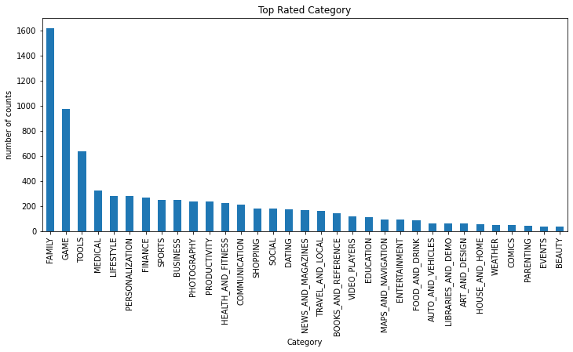

```python
plt.figure(figsize=(12,5))
data_train['Category'].value_counts().plot(kind ='bar')
plt.xlabel('Category')
plt.ylabel('number of counts')
plt.title('Top Rated Category')
```

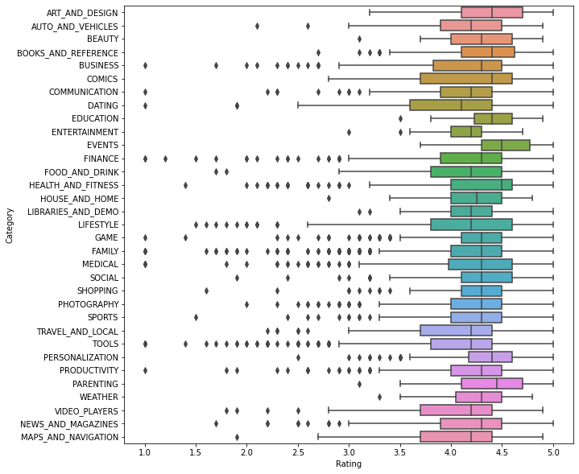

```python
plt.figure(figsize=(10,10))
sns.boxplot(x='Rating', y ='Category', data=data_train)
```

here we can see the category wise rating given for apps (1) The rating given for category events is in between 4 and 5

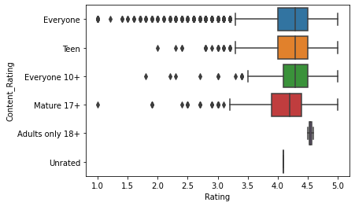

```python
sns.boxplot(x= 'Rating', y= 'Content_Rating', data = data_train)
```

here we can see:- The content rating given by adult only 18+ is having a range greater than 4.5 Content rating given by everyone varies from 1 to 5

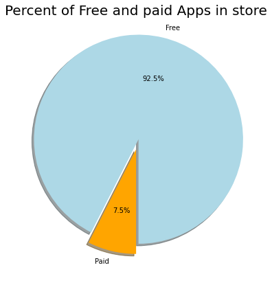

```python
labels =data_train['Type'].value_counts(sort = True).index
sizes = data_train['Type'].value_counts(sort = True)
colors = ["lightblue","orange"]
explode = (0.1,0)  # explode 1st slice
plt.figure(figsize=(7,7))
plt.pie(sizes, explode=explode, labels=labels, colors=colors,
        autopct='%1.1f%%', shadow=True, startangle=270,)

plt.title('Percent of Free and paid Apps in store',size = 20)
plt.show()
```

Here we can see that 92.5% of the apps are free and only about 7.5% of apps are paid.

```
Rating         AxesSubplot(0.125,0.787927;0.352273x0.0920732)
Reviews     AxesSubplot(0.547727,0.787927;0.352273x0.0920732)
Size           AxesSubplot(0.125,0.677439;0.352273x0.0920732)
Installs    AxesSubplot(0.547727,0.677439;0.352273x0.0920732)
Price          AxesSubplot(0.125,0.566951;0.352273x0.0920732)
dtype: object
```

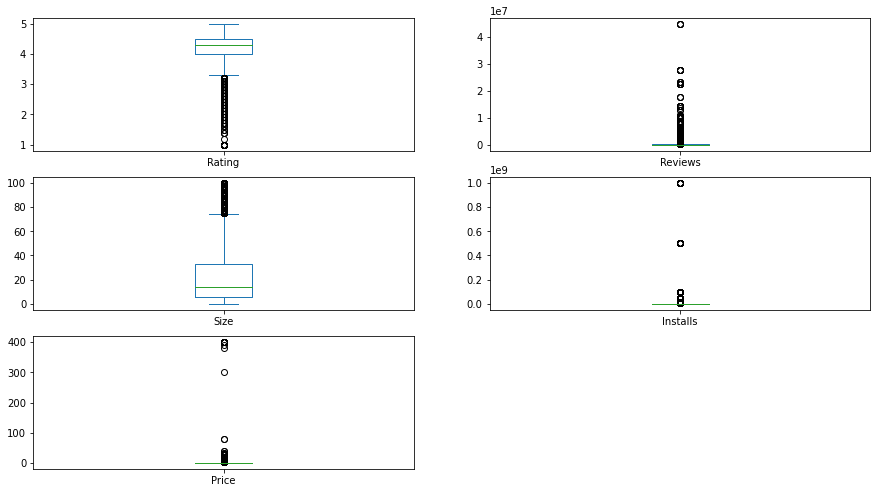

```python
data_train.plot(kind ='box',subplots =True,layout =(7,2),figsize=(15,20))
```

```python
data_train.skew()
```

```
Rating      -1.750270
Reviews     13.637104
Size         1.433736
Installs    13.837674
Price       22.177805
dtype: float64
```

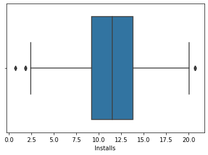

```python
data_train.Installs=np.log1p(data_train.Installs)
sns.boxplot(x='Installs',data=data_train)
```

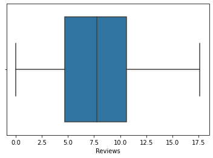

```python
data_train.Reviews=np.log(data_train.Reviews)
sns.boxplot(x='Reviews',data=data_train)
```

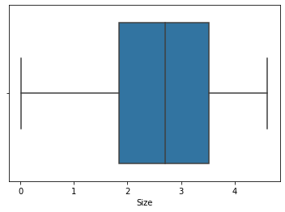

```python
data_train.Size=np.log1p(data_train.Size)
sns.boxplot(x="Size",data=data_train)
```

```python
non_zero_prices = data_train[data_train['Price'] > 0]['Price']
zero_prices = data_train[data_train['Price'] == 0]['Price']
len(non_zero_prices),len(zero_prices)
```

```
(579, 7150)
```

```python
q1, q3 = np.percentile(non_zero_prices, [25, 75])
iqr = q3 - q1
lower_bound = q1 - 1.5 * iqr
upper_bound = q3 + 1.5 * iqr

outliers = non_zero_prices[(non_zero_prices < lower_bound) | (non_zero_prices > upper_bound)]
ind =  non_zero_prices[(non_zero_prices > upper_bound) | (non_zero_prices < lower_bound)].index
non_zero_prices=non_zero_prices.drop(ind)
```

```python
data_train['Price'] = pd.concat([zero_prices, non_zero_prices])
data_train['Price'].drop_duplicates(inplace=True)
```

```python
data_train.isnull().sum()
```

```
Category           0
Rating             0
Reviews            0
Size               0
Installs           0
Type               0
Price             87
Content_Rating     0
Genres             0
dtype: int64
```

```python
data_train.dropna(subset=['Price'],inplace =True)
```

```python
data_train.skew()
```

```
Rating     -1.756683
Reviews     0.032402
Size       -0.187369
Installs   -0.249587
Price       5.345331
dtype: float64
```

```python
data_train.isnull().sum()
```

```
Category          0
Rating            0
Reviews           0
Size              0
Installs          0
Type              0
Price             0
Content_Rating    0
Genres            0
dtype: int64
```

```python
from sklearn.preprocessing import LabelEncoder
le = LabelEncoder()
```

```python
data_train['Category']=le.fit_transform(data_train['Category'])
data_train['Type'] =le.fit_transform(data_train['Type'])
data_train['Content_Rating'] =le.fit_transform(data_train['Content_Rating'])
data_train['Genres']=le.fit_transform(data_train['Genres'])
```

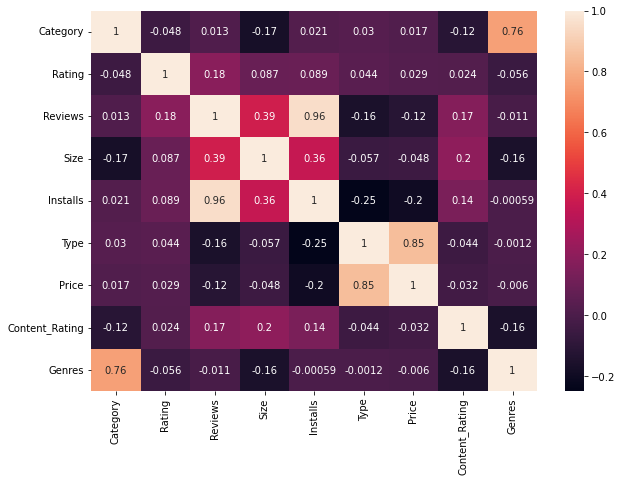

```python
corr =data_train.corr()
plt.figure(figsize=(10,7))
sns.heatmap(corr,annot =True)
```

Here by seeing the corelation heat map (1) There is strong positive corelation between Installs and Reviews (2) Strong positive corelation between Price and Type (3) Positive corelation between Generes and Category

```python
data_train.head()
```

|  | Category | Rating | Reviews | Size | Installs | Type | Price | Content_Rating | Genres |
| --- | --- | --- | --- | --- | --- | --- | --- | --- | --- |
| 0 | 0 | 4.1 | 5.068904 | 2.995732 | 9.210440 | 0 | 0.0 | 1 | 9 |
| 1 | 0 | 3.9 | 6.874198 | 2.708050 | 13.122365 | 0 | 0.0 | 1 | 11 |
| 2 | 0 | 4.7 | 11.379508 | 2.272126 | 15.424949 | 0 | 0.0 | 1 | 9 |
| 3 | 0 | 4.5 | 12.281384 | 3.258097 | 17.727534 | 0 | 0.0 | 4 | 9 |
| 4 | 0 | 4.3 | 6.874198 | 1.335001 | 11.512935 | 0 | 0.0 | 1 | 10 |

```python
#cleaning the test dataset
data_test.drop('Rating',axis =1,inplace =True)
```

```python
data_test.isnull().sum()
```

```
Category          0
Reviews           0
Size              0
Installs          0
Type              1
Price             0
Content_Rating    0
Genres            0
dtype: int64
```

```python
data_test.dropna(subset=['Size'],inplace=True)
```

```python
data_test.info()
```

```
<class 'pandas.core.frame.DataFrame'>
Int64Index: 1474 entries, 23 to 10838
Data columns (total 8 columns):
 #   Column          Non-Null Count  Dtype
---  ------          --------------  -----
 0   Category        1474 non-null   object
 1   Reviews         1474 non-null   object
 2   Size            1474 non-null   object
 3   Installs        1474 non-null   object
 4   Type            1473 non-null   object
 5   Price           1474 non-null   object
 6   Content_Rating  1474 non-null   object
 7   Genres          1474 non-null   object
dtypes: object(8)
memory usage: 103.6+ KB
```

```python
data_test['Size'] = data_test['Size'].apply(lambda x : str(x).replace('M',''))
data_test['Size'] = data_test['Size'].apply(lambda x : str(x).replace('+',''))
data_test['Size'] = data_test['Size'].apply(lambda x : str(x).replace(',',''))
data_test['Size'] = data_test['Size'].apply(lambda x : str(x).replace('Varies with device','nan'))
data_test['Size'] = data_test['Size'].apply(lambda x :float(str(x).replace('k',''))/1000 if 'k' in str(x) else x)
data_test['Size']= data_test['Size'].astype(float)
data_test.dropna(subset=['Size'],inplace =True)
```

```python
data_test['Reviews']= data_test['Reviews'].astype(float)
```

```python
data_test['Installs'] = data_test['Installs'].apply(lambda x : str(x).replace('+',''))
data_test['Installs'] = data_test['Installs'].apply(lambda x : str(x).replace('Free','nan'))
data_test['Installs'] = data_test['Installs'].apply(lambda x : str(x).replace(',',''))
data_test['Installs'] = data_test['Installs'].astype(float)
data_test.dropna(subset=['Installs'],inplace =True)
```

```python
data_test['Price']= data_test['Price'].apply(lambda x :str(x).replace('$',''))
data_test['Price']= data_test['Price'].apply(lambda x :str(x).replace('Everyone','nan'))
data_test['Price']= data_test["Price"].astype(float)
data_test.dropna(subset=['Price'],inplace =True)
```

```python
data_test['Category']=le.fit_transform(data_test['Category'])
data_test['Type'] =le.fit_transform(data_test['Type'])
data_test['Content_Rating'] =le.fit_transform(data_test['Content_Rating'])
data_test['Genres']=le.fit_transform(data_test['Genres'])
```

```python
data_test.isnull().sum()
```

```
Category          0
Reviews           0
Size              0
Installs          0
Type              0
Price             0
Content_Rating    0
Genres            0
dtype: int64
```

```python
data_test.info()
```

```
<class 'pandas.core.frame.DataFrame'>
Int64Index: 1416 entries, 23 to 10838
Data columns (total 8 columns):
 #   Column          Non-Null Count  Dtype
---  ------          --------------  -----
 0   Category        1416 non-null   int32
 1   Reviews         1416 non-null   float64
 2   Size            1416 non-null   float64
 3   Installs        1416 non-null   float64
 4   Type            1416 non-null   int32
 5   Price           1416 non-null   float64
 6   Content_Rating  1416 non-null   int32
 7   Genres          1416 non-null   int32
dtypes: float64(4), int32(4)
memory usage: 77.4 KB
```

```python
data_test.shape
```

```
(1416, 8)
```

```python
data_test.describe()
```

|  | Category | Reviews | Size | Installs | Type | Price | Content_Rating | Genres |
| --- | --- | --- | --- | --- | --- | --- | --- | --- |
| count | 1416.000000 | 1416.000000 | 1416.000000 | 1416.000000 | 1416.000000 | 1416.000000 | 1416.000000 | 1416.000000 |
| mean | 15.471751 | 18.532486 | 13.650649 | 3228.210452 | 0.102401 | 1.494138 | 0.318503 | 28.946328 |
| std | 8.540689 | 142.665550 | 14.898143 | 31825.351740 | 0.303282 | 17.107783 | 0.885436 | 13.633774 |
| min | 0.000000 | 0.000000 | 0.018000 | 0.000000 | 0.000000 | 0.000000 | 0.000000 | 0.000000 |
| 25% | 10.000000 | 0.000000 | 3.600000 | 10.000000 | 0.000000 | 0.000000 | 0.000000 | 17.000000 |
| 50% | 15.000000 | 1.000000 | 8.700000 | 100.000000 | 0.000000 | 0.000000 | 0.000000 | 30.000000 |
| 75% | 23.000000 | 5.000000 | 19.000000 | 500.000000 | 0.000000 | 0.000000 | 0.000000 | 39.000000 |
| max | 31.000000 | 3248.000000 | 99.000000 | 1000000.000000 | 1.000000 | 399.990000 | 4.000000 | 55.000000 |

```python
data_train
```

|  | Category | Rating | Reviews | Size | Installs | Type | Price | Content_Rating | Genres |
| --- | --- | --- | --- | --- | --- | --- | --- | --- | --- |
| 0 | 0 | 4.1 | 5.068904 | 2.995732 | 9.210440 | 0 | 0.0 | 1 | 9 |
| 1 | 0 | 3.9 | 6.874198 | 2.708050 | 13.122365 | 0 | 0.0 | 1 | 11 |
| 2 | 0 | 4.7 | 11.379508 | 2.272126 | 15.424949 | 0 | 0.0 | 1 | 9 |
| 3 | 0 | 4.5 | 12.281384 | 3.258097 | 17.727534 | 0 | 0.0 | 4 | 9 |
| 4 | 0 | 4.3 | 6.874198 | 1.335001 | 11.512935 | 0 | 0.0 | 1 | 10 |
| ... | ... | ... | ... | ... | ... | ... | ... | ... | ... |
| 10833 | 3 | 4.8 | 3.784190 | 0.481809 | 6.908755 | 0 | 0.0 | 1 | 18 |
| 10834 | 11 | 4.0 | 1.945910 | 1.280934 | 6.216606 | 0 | 0.0 | 1 | 36 |
| 10836 | 11 | 4.5 | 3.637586 | 3.988984 | 8.517393 | 0 | 0.0 | 1 | 36 |
| 10837 | 11 | 5.0 | 1.386294 | 1.526056 | 4.615121 | 0 | 0.0 | 1 | 36 |
| 10840 | 18 | 4.5 | 12.894978 | 2.995732 | 16.118096 | 0 | 0.0 | 1 | 64 |

7642 rows × 9 columns

## Spliting to X and Y

```python
x =data_train.drop(columns=['Rating'])
y =data_train.iloc[:,1]
test_x = data_test.iloc[:,:]
```

```python
x.shape,y.shape,test_x.shape
```

```
((7642, 8), (7642,), (1416, 8))
```

## Model building

```python
from sklearn.model_selection import train_test_split
x_train,x_test,y_train,y_test = train_test_split(x,y,test_size = .2,random_state = 0)
x_train.shape,x_test.shape,y_train.shape,y_test.shape
```

```
((6113, 8), (1529, 8), (6113,), (1529,))
```

## Linear Reg

```python
from sklearn.linear_model import LinearRegression
from sklearn.metrics import r2_score, mean_squared_error, mean_absolute_error

lr=LinearRegression()
```

```python
lr.fit(x_train,y_train)
```

```
LinearRegression()
```

```python
y_pred=lr.predict(x_test)
```

```python
y_pred
```

```
array([4.08413508, 4.36178817, 4.04048747, ..., 3.91847543, 3.93896625,
       4.51543687])
```

```python
Linear_mse=print(mean_squared_error(y_test,y_pred))
```

```
0.24509801053937358
```

```python
mean_absolute_error(y_test,y_pred)
```

```
0.3449720241702214
```

## XG Boost

```python
import xgboost as xgb
```

```python
xboost = xgb.XGBRegressor(n_estimators=100,reg_lambda=1,gamma=0,max_depth=3)
```

```python
xboost.fit(x_train,y_train)
```

```
XGBRegressor(base_score=None, booster=None, callbacks=None,
             colsample_bylevel=None, colsample_bynode=None,
             colsample_bytree=None, early_stopping_rounds=None,
             enable_categorical=False, eval_metric=None, feature_types=None,
             gamma=0, gpu_id=None, grow_policy=None, importance_type=None,
             interaction_constraints=None, learning_rate=None, max_bin=None,
             max_cat_threshold=None, max_cat_to_onehot=None,
             max_delta_step=None, max_depth=3, max_leaves=None,
             min_child_weight=None, missing=nan, monotone_constraints=None,
             n_estimators=100, n_jobs=None, num_parallel_tree=None,
             predictor=None, random_state=None, ...)
```

```python
pred_xg= xboost.predict(x_test)
pred_xg
```

```
array([3.9618556, 4.8198113, 4.15118  , ..., 4.0008774, 4.449151 ,
       4.4551287], dtype=float32)
```

```python
mean_squared_error(y_test,pred_xg)
```

```
0.2385092549473835
```

```python
mean_absolute_error(y_test,pred_xg)
```

```
0.3311895164342547
```

## Random Forest Regressor

```python
from sklearn.ensemble import RandomForestRegressor
```

```python
randomf = RandomForestRegressor(n_estimators=300)
randomf.fit(x_train, y_train)
```

```
RandomForestRegressor(n_estimators=300)
```

```python
rand=randomf.predict(x_test)
```

```python
mean_squared_error(y_test,rand)
```

```
0.2385357854497211
```

```python
mean_absolute_error(y_test,rand)
```

```
0.3238644248237775
```

Here while comparing the MSE and MAE of LR ,XG boost and Random forest Regressor we can choose the model of Random forest Regressor which is having a MSE:-.23 and MAE:-.32

### Lasso Regression

```python
from sklearn.model_selection import cross_val_score
from sklearn.linear_model import Lasso
alphas = np.logspace(-4, 2, 50)
cv_scores = []
for alpha in alphas:
    lasso = Lasso(alpha=alpha)
    scores = cross_val_score(lasso, x_train, y_train, cv=10, scoring='neg_mean_squared_error')
    cv_scores.append(-1 * np.mean(scores))
optimal_alpha = alphas[np.argmin(cv_scores)]
print("Optimal alpha value:", optimal_alpha)
```

```
Optimal alpha value: 0.0016768329368110084
```

```python
lasso =Lasso(alpha=.0016)
```

```python
lasso.fit(x_train,y_train)
```

```
Lasso(alpha=0.0016)
```

```python
coef = pd.Series(lasso.coef_, index = x.columns)
```

```python
las_pre =lasso.predict(x_test)
las_pre
```

```
array([4.08643481, 4.36217403, 4.0445705 , ..., 3.92226345, 3.94154665,
       4.51206789])
```

```python
Lr2=lasso.score(x_train,y_train)
Lr2
```

```
0.11790447392824055
```

```python
Ladr2=1-(((1-Lr2)*(5349-1))/(5349-8-1))
Ladr2
```

```
0.11658298250341392
```

```python
print("Lasso picked " + str(sum(coef != 0)) + " features and eliminated the other " +  str(sum(coef == 0)) + " features")
print("Selected features:")
print(coef[coef != 0])
```

```
Lasso picked 6 features and eliminated the other 2 features
Selected features:
Category         -0.000652
Reviews           0.162796
Installs         -0.143723
Price            -0.016003
Content_Rating   -0.019057
Genres           -0.000705
dtype: float64
```

```python
X=x.drop(columns=['Size','Type'])
```

```python
X.shape,y.shape
```

```
((7642, 6), (7642,))
```

```python
from sklearn.model_selection import train_test_split
X_train,X_test,Y_train,Y_test = train_test_split(X,y,test_size = .3,random_state = 100)
X_train.shape,X_test.shape,Y_train.shape,Y_test.shape
```

```
((5349, 6), (2293, 6), (5349,), (2293,))
```

## After Lasso

### LR

```python
lrs=LinearRegression()
```

```python
lrs.fit(X_train,Y_train)
```

```
LinearRegression()
```

```python
y_predlas=lrs.predict(X_test)
```

```python
y_predlas
```

```
array([4.35556685, 4.25923456, 4.54280656, ..., 4.19380253, 4.31400647,
       4.147558  ])
```

```python
mean_squared_error(Y_test,y_predlas)
```

```
0.2704418393701061
```

```python
mean_absolute_error(Y_test,y_predlas)
```

```
0.3583723498724233
```

### XG boost

```python
xboost.fit(X_train,Y_train)
```

```
XGBRegressor(base_score=None, booster=None, callbacks=None,
             colsample_bylevel=None, colsample_bynode=None,
             colsample_bytree=None, early_stopping_rounds=None,
             enable_categorical=False, eval_metric=None, feature_types=None,
             gamma=0, gpu_id=None, grow_policy=None, importance_type=None,
             interaction_constraints=None, learning_rate=None, max_bin=None,
             max_cat_threshold=None, max_cat_to_onehot=None,
             max_delta_step=None, max_depth=3, max_leaves=None,
             min_child_weight=None, missing=nan, monotone_constraints=None,
             n_estimators=100, n_jobs=None, num_parallel_tree=None,
             predictor=None, random_state=None, ...)
```

```python
pred_xg1= xboost.predict(X_test)
pred_xg1
```

```
array([4.449799 , 4.287659 , 4.4930115, ..., 4.0838056, 4.123366 ,
       3.953321 ], dtype=float32)
```

```python
mean_squared_error(Y_test,pred_xg1)
```

```
0.2595617265093727
```

```python
mean_absolute_error(Y_test,pred_xg1)
```

```
0.3487354403128543
```

## Random Forest regressor

```python
randomf = RandomForestRegressor(n_estimators=300)
randomf.fit(X_train, Y_train)
```

```
RandomForestRegressor(n_estimators=300)
```

```python
ran=randomf.predict(X_test)
```

```python
mean_squared_error(Y_test,ran)
```

```
0.2971646534407247
```

```python
mean_absolute_error(Y_test,ran)
```

```
0.35727828565754316
```

After using lasso Regression method we are getting for Xg Boost MSE as .2595 and MAE as .34873